# The Effect of Mental Health and Sleep on College Students' Academic Performance

#### Sneha Sureshanand & Ananya Vepa

## Introduction

College students face an immense amount of pressure as they look to prepare themselves for their careers. This pressure manifests itself in different ways for students with two of the biggest ones being mental health and sleep habits. Mental health is one of the most influential factors in the way a college student functions especially when considering the fact that “more than 60% of college students met the criteria for at least one mental health problem” during the 2020-2021 school according to the Healthy Minds Study and highlighted by the American Psychological Association (Abrams, 2022). With such a significant amount of students struggling with their mental health, we questioned whether students’ academic performance is likely to be impacted in some way and to what degree. We were interested in seeing how students struggling with things like depression, anxiety, and stress balanced school on top of dealing with their mental health and understanding the degree to which their performance is affected because of these problems. Additionally, sleep, or lack thereof, is also known to be a fallout of the pressure that students face. As they look to do well in classes and juggle many of the other things they are working on, students tend to sacrifice sleep in order to have more time in the day. Knowing this, we were interested in seeing how this sacrifice and general sleep habits of students play a role in students’ academic performance.

The article by the American Psychological Association is linked [here](https://www.apa.org/monitor/2022/10/mental-health-campus-care).

In this tutorial, our purpose is to understand how students’ average sleep and mental health problems such as depression, anxiety, and stress influence academic performance as measured by GPA. By using the SleepStudy dataset (which will be explained further in the Data Collection section), we were able to clean the data to perform exploratory analysis and then develop two models, a linear regression model and a random forest model. The linear regression model will be used to identify the degree to which each of the mental health problems(depression, anxiety, stress) and amount of sleep affect GPA and if there is a linear relationship between the predictors and the response (GPA). The random forest model will be used to further examine whether or not there is a relationship between mental health problems and sleep vs GPA that can be portrayed by a machine learning model.

## Data Collection

We will start by importing the libraries that will be used throughout this project. These libraries include [pandas](https://pandas.pydata.org/pandas-docs/stable/#), [matplotlib](https://matplotlib.org/stable/plot_types/index.html), [seaborn](https://seaborn.pydata.org/index.html), [sklearn](https://scikit-learn.org/stable/getting_started.html), [statsmodel](https://www.statsmodels.org/stable/index.html), and [numpy](https://numpy.org/doc/stable/user/quickstart.html). Each of these libraries allows us to perform data loading and wrangling, visualization, and the creation and use of models.

```python
# Imports necessary libraries
import pandas as pd
import matplotlib.pyplot as plt
import seaborn as sns
import matplotlib.dates as mdates
from sklearn import linear_model
import statsmodels.api as sm
import numpy as np
from sklearn.ensemble import RandomForestRegressor
from sklearn.tree import DecisionTreeClassifier
from sklearn.model_selection import GridSearchCV, train_test_split, cross_val_score
from sklearn.metrics import mean_squared_error
```

The dataset that we will be using comes from the Lock5withR package that is linked to the R programming language. This package contains around 95 datasets that can be imported into RStudio and used for analysis purposes. One of the datasets from this package, SleepStudy, was intriguing because of the information that it showed so we decided to use it. In order to get this data, we had to download the Lock5withR package into RStudio and then import the SleepStudy dataset. We then had to write that dataset to the form of a CSV (Comma Separated Value) file so it could be exported and used for this project. This conversion has been done for you and you can found the dataset [here](https://github.com/ananyav03/ananyav03.github.io/blob/main/SleepStudy%20Dataset.csv).

### Reading the Data

```python
df = pd.read_csv('/Users/ananyavepa/Documents/Fall 2022/CMSC320/Final Project/SleepStudy Dataset.csv')
df.head()
```

|  | Gender | ClassYear | LarkOwl | NumEarlyClass | EarlyClass | GPA | ClassesMissed | CognitionZscore | PoorSleepQuality | DepressionScore | ... | WeekdayRise | WeekdaySleep | WeekendBed | WeekendRise | WeekendSleep | AverageSleep | AllNighter | Sex | allNighter | earlyClass |
| --- | --- | --- | --- | --- | --- | --- | --- | --- | --- | --- | --- | --- | --- | --- | --- | --- | --- | --- | --- | --- | --- |
| 0 | 0 | 4 | Neither | 0 | 0 | 3.60 | 0 | -0.26 | 4 | 4 | ... | 8.70 | 7.70 | 25.75 | 9.50 | 5.88 | 7.18 | 0 | Female | No | No |
| 1 | 0 | 4 | Neither | 2 | 1 | 3.24 | 0 | 1.39 | 6 | 1 | ... | 8.20 | 6.80 | 26.00 | 10.00 | 7.25 | 6.93 | 0 | Female | No | Yes |
| 2 | 0 | 4 | Owl | 0 | 0 | 2.97 | 12 | 0.38 | 18 | 18 | ... | 6.55 | 3.00 | 28.00 | 12.59 | 10.09 | 5.02 | 0 | Female | No | No |
| 3 | 0 | 1 | Lark | 5 | 1 | 3.76 | 0 | 1.39 | 9 | 1 | ... | 7.17 | 6.77 | 27.00 | 8.00 | 7.25 | 6.90 | 0 | Female | No | Yes |
| 4 | 0 | 4 | Owl | 0 | 0 | 3.20 | 4 | 1.22 | 9 | 7 | ... | 8.67 | 6.09 | 23.75 | 9.50 | 7.00 | 6.35 | 0 | Female | No | No |

5 rows × 30 columns

The descripition of the remaining columns can be found on pages 63 and 64 of [this document](https://cran.r-project.org/web/packages/Lock5withR/Lock5withR.pdf).

This dataset was creatted using data from a study done to identify sleep patterns of a sample of college students who completed skills tests to measure cognitive function, completed a survey that asked questions about attitudes and habits, and kept a record of time and quality of sleep over a two week period (description obtained from [Datasets for 'Statistics: Unlocking the Power of Data'](https://cran.r-project.org/web/packages/Lock5withR/Lock5withR.pdf).

### Cleaning and Modifying the Data

The first step to cleaning the data is eliminating any rows that have null values. The reason that we do this is because null values prevent machine learning algorithms from creating accurate models. The missing data can cause bias when estimating parameters in the model as the model may not have enough information accurately create a value/coefficient. If the dataset has a sufficient amount of samples, we can just remove the row/column in which there is a null value. Consider removing row if there's one or more null value, and consider removing a column if there are several null values (over 255). However, only do this if there is a sufficient enough of data after dropping all the null values, otherwise you may risk underfitting the model since there is not enough data to effectively train the model. If you do not have enough data to delete null rows/columns, consider replacing the null values with an arbitrary value. For instance, this can include filling in a null value in a numerical column with 0.

```python
# Drops rows with null values in any of the columns
df = df.dropna()
# Verifies that there are no null values
df.isnull().values.any()
```

```
False
```

There are several columns in the original dataset that we are not using as part of this study. We remove these columns from the dataset for 2 main reasons. The first being it is much easier to read and understand the dataset as there is no extraneous information being presented. The second is removing fields that are not being used can drastically improve the speed at which code executes. In this particular case, we are dropping 10 columns, which means that each time the code is run, it will have significantly less information to read/process than if it were to process the original dataset.

```python
# Dropping ClassYear, LarkOwl, NumEarlyClass, EarlyClass, CognitionZscore, WeekdayBed, WeekendBed, AllNighter,
# allNighter, earlyClass columns
df.drop(['ClassYear', 'LarkOwl', 'NumEarlyClass', 'EarlyClass', 'CognitionZscore', 'WeekdayRise',
        'WeekendRise', 'AllNighter', 'allNighter', 'earlyClass'], axis = 1, inplace = True)
df.head()
```

|  | Gender | GPA | ClassesMissed | PoorSleepQuality | DepressionScore | AnxietyScore | StressScore | DepressionStatus | AnxietyStatus | Stress | DASScore | Happiness | AlcoholUse | Drinks | WeekdayBed | WeekdaySleep | WeekendBed | WeekendSleep | AverageSleep | Sex |
| --- | --- | --- | --- | --- | --- | --- | --- | --- | --- | --- | --- | --- | --- | --- | --- | --- | --- | --- | --- | --- |
| 0 | 0 | 3.60 | 0 | 4 | 4 | 3 | 8 | normal | normal | normal | 15 | 28 | Moderate | 10 | 25.75 | 7.70 | 25.75 | 5.88 | 7.18 | Female |
| 1 | 0 | 3.24 | 0 | 6 | 1 | 0 | 3 | normal | normal | normal | 4 | 25 | Moderate | 6 | 25.70 | 6.80 | 26.00 | 7.25 | 6.93 | Female |
| 2 | 0 | 2.97 | 12 | 18 | 18 | 18 | 9 | moderate | severe | normal | 45 | 17 | Light | 3 | 27.44 | 3.00 | 28.00 | 10.09 | 5.02 | Female |
| 3 | 0 | 3.76 | 0 | 9 | 1 | 4 | 6 | normal | normal | normal | 11 | 32 | Light | 2 | 23.50 | 6.77 | 27.00 | 7.25 | 6.90 | Female |
| 4 | 0 | 3.20 | 4 | 9 | 7 | 25 | 14 | normal | severe | normal | 46 | 15 | Moderate | 4 | 25.90 | 6.09 | 23.75 | 7.00 | 6.35 | Female |

```python
weekendSummary = df['WeekendBed'].describe()
weekdaySummary = df['WeekdayBed'].describe()
print("Weekend Summary:\n", weekendSummary)
print("\n")
print("Weekday Summary:\n", weekdaySummary)
```

```
Weekend Summary:
 count    253.000000
mean      25.584585
std        1.273104
min       21.500000
25%       24.880000
50%       25.500000
75%       26.250000
max       30.250000
Name: WeekendBed, dtype: float64


Weekday Summary:
 count    253.000000
mean      24.847708
std        1.033697
min       21.800000
25%       24.200000
50%       24.800000
75%       25.500000
max       29.100000
Name: WeekdayBed, dtype: float64
```

Before conducting our exploratory analysis, we realized that we wanted to see the effect of the time people go to bed on the amount of hours of sleep they get. The fields 'WeekendBed' and 'WeekdayBed' represent the time people go to sleep. However, in both of these fields, the time is represented in decimal format. Also, if a person goes to bed after midnight that day, the hour is marked as 24 + the number of hours past midnight, which is an invalid time. For instance, if they go to bed at 1:30 am on a weekday, the 'WeekdayBed' field will read '25.5'. To do a proper time-series analysis, we have to convert these fields from decimal to datetime format. To do so, we first go through all the values in the 'WeekendBed' column and if the decimal time is greater than 24, we change the decimal to that value minus 24 to get the actual hour. We then append "am" to a newly created 'WeekendAMPM' column that tells whether the time represents morning or afternoon. If the time is within the 24 hours, its decimal value is retained and the time at which they go to bed is marked as "pm", since none of the data showed that people went to bed prior to 21.5 (9:30pm). We repeated the process for the "WeekdayBed" column.

*Data to retrieve minimum time at which people go to bed is shown above - demonstrated by summary stats of 'WeekendBed' and 'WeekdayBed' columns*

```python
# Converts invalid hours like 25:45 to correct time and adjusts am/pm value
ampm = []
# Goes through all the values in the 'WeekendBed' column
for i in range(0, len(df['WeekendBed'])):
    # If the decimal time is greater than 24, we change the decimal to that value minus 24 to get the actual hour.
    if df['WeekendBed'].iloc[i] >= 24:
        df['WeekendBed'].iloc[i] = (df['WeekendBed'].iloc[i] - 24)
        # Append "am" to tell that the time represents morning
        ampm.append('AM')
    else:
        # If decimal time is within the day, append "pm" to tell that the time represents night
        ampm.append('PM')
# Creates a new field that represent whether the time people go to sleep on weekends is am or pm
df['WeekendAMPM'] = ampm

ampm.clear()
# Goes through all the values in the 'WeekdayBed' column
for i in range(0, len(df['WeekdayBed'])):
    # If the decimal time is greater than 24, we change the decimal to that value minus 24 to get the actual hour.
    if df['WeekdayBed'].iloc[i] >= 24:
        df['WeekdayBed'].iloc[i] = (df['WeekdayBed'].iloc[i] - 24)
        # Append "am" to tell that the time represents morning
        ampm.append('AM')
    else:
        # If decimal time is within the day, append "pm" to tell that the time represents night
        ampm.append('PM')
# Creates a new field that represent whether the time people go to sleep on weekdays is am or pm
df['WeekdayAMPM'] = ampm
df.head()
```

|  | Gender | GPA | ClassesMissed | PoorSleepQuality | DepressionScore | AnxietyScore | StressScore | DepressionStatus | AnxietyStatus | Stress | ... | AlcoholUse | Drinks | WeekdayBed | WeekdaySleep | WeekendBed | WeekendSleep | AverageSleep | Sex | WeekendAMPM | WeekdayAMPM |
| --- | --- | --- | --- | --- | --- | --- | --- | --- | --- | --- | --- | --- | --- | --- | --- | --- | --- | --- | --- | --- | --- |
| 0 | 0 | 3.60 | 0 | 4 | 4 | 3 | 8 | normal | normal | normal | ... | Moderate | 10 | 1.75 | 7.70 | 1.75 | 5.88 | 7.18 | Female | AM | AM |
| 1 | 0 | 3.24 | 0 | 6 | 1 | 0 | 3 | normal | normal | normal | ... | Moderate | 6 | 1.70 | 6.80 | 2.00 | 7.25 | 6.93 | Female | AM | AM |
| 2 | 0 | 2.97 | 12 | 18 | 18 | 18 | 9 | moderate | severe | normal | ... | Light | 3 | 3.44 | 3.00 | 4.00 | 10.09 | 5.02 | Female | AM | AM |
| 3 | 0 | 3.76 | 0 | 9 | 1 | 4 | 6 | normal | normal | normal | ... | Light | 2 | 23.50 | 6.77 | 3.00 | 7.25 | 6.90 | Female | AM | PM |
| 4 | 0 | 3.20 | 4 | 9 | 7 | 25 | 14 | normal | severe | normal | ... | Moderate | 4 | 1.90 | 6.09 | 23.75 | 7.00 | 6.35 | Female | PM | AM |

5 rows × 22 columns

The following code converts the decimal time in the 'WeekendBed' and 'WeekdayBed' columns to a string in the format hh:mm:ss.

```python
temp = []
# Goes through all the values in the 'WeekendBed' column
for x in df['WeekendBed']:
    # Stores int (left hand side of the decimal) as the hour
    hrs = int(x)
    # Converts decimal to get the number of minutes
    mins = (x*60)%60
    # Converts decimal to get the number of seconds
    secs = (x*3600)%60
    # Appends the time in hh:mm:ss format to a list
    temp.append("%d:%02d:%02d" % (hrs, mins, secs))
# The 'WeekendBed' field is replaced with values in the hh:mm:ss time format
df['WeekendBed'] = temp

temp.clear()
# Goes through all the values in the 'WeekdayBed' column
for x in df['WeekdayBed']:
    # Stores int (left hand side of the decimal) as the hour
    hrs = int(x)
    # Converts decimal to get the number of minutes
    mins = (x*60)%60
    # Converts decimal to get the number of seconds
    secs = (x*3600)%60
    # Appends the time in hh:mm:ss format to a list
    temp.append("%d:%02d:%02d" % (hrs, mins, secs))
# The 'WeekdayBed' field is replaced with values in the hh:mm:ss time format
df['WeekdayBed'] = temp
df.head()
```

|  | Gender | GPA | ClassesMissed | PoorSleepQuality | DepressionScore | AnxietyScore | StressScore | DepressionStatus | AnxietyStatus | Stress | ... | AlcoholUse | Drinks | WeekdayBed | WeekdaySleep | WeekendBed | WeekendSleep | AverageSleep | Sex | WeekendAMPM | WeekdayAMPM |
| --- | --- | --- | --- | --- | --- | --- | --- | --- | --- | --- | --- | --- | --- | --- | --- | --- | --- | --- | --- | --- | --- |
| 0 | 0 | 3.60 | 0 | 4 | 4 | 3 | 8 | normal | normal | normal | ... | Moderate | 10 | 1:45:00 | 7.70 | 1:45:00 | 5.88 | 7.18 | Female | AM | AM |
| 1 | 0 | 3.24 | 0 | 6 | 1 | 0 | 3 | normal | normal | normal | ... | Moderate | 6 | 1:41:59 | 6.80 | 2:00:00 | 7.25 | 6.93 | Female | AM | AM |
| 2 | 0 | 2.97 | 12 | 18 | 18 | 18 | 9 | moderate | severe | normal | ... | Light | 3 | 3:26:24 | 3.00 | 4:00:00 | 10.09 | 5.02 | Female | AM | AM |
| 3 | 0 | 3.76 | 0 | 9 | 1 | 4 | 6 | normal | normal | normal | ... | Light | 2 | 23:30:00 | 6.77 | 3:00:00 | 7.25 | 6.90 | Female | AM | PM |
| 4 | 0 | 3.20 | 4 | 9 | 7 | 25 | 14 | normal | severe | normal | ... | Moderate | 4 | 1:53:59 | 6.09 | 23:45:00 | 7.00 | 6.35 | Female | PM | AM |

5 rows × 22 columns

Convert the newly adjusted 'WeekendBed' and 'WeekdayBed' columns from string to a datetime format. This will allow us to properly construct timeseries graphs as the time will be read as a time value and not a string. If the time is read at a string, it would be difficult to show values over time as it will be registered as categorical data with hundred of different categories since each "time" will be its own. However, by converting it to datetime format, the data will be read as a continuous variable instead of a discrete/categorical one, which allows us to better understand values relative to eachother.

```python
# Converts to datatime format
df['WeekendBed']= pd.to_datetime(df['WeekendBed'])
df['WeekdayBed']= pd.to_datetime(df['WeekdayBed'])
df.info()
```

```
<class 'pandas.core.frame.DataFrame'>
RangeIndex: 253 entries, 0 to 252
Data columns (total 22 columns):
 #   Column            Non-Null Count  Dtype
---  ------            --------------  -----
 0   Gender            253 non-null    int64
 1   GPA               253 non-null    float64
 2   ClassesMissed     253 non-null    int64
 3   PoorSleepQuality  253 non-null    int64
 4   DepressionScore   253 non-null    int64
 5   AnxietyScore      253 non-null    int64
 6   StressScore       253 non-null    int64
 7   DepressionStatus  253 non-null    object
 8   AnxietyStatus     253 non-null    object
 9   Stress            253 non-null    object
 10  DASScore          253 non-null    int64
 11  Happiness         253 non-null    int64
 12  AlcoholUse        253 non-null    object
 13  Drinks            253 non-null    int64
 14  WeekdayBed        253 non-null    datetime64[ns]
 15  WeekdaySleep      253 non-null    float64
 16  WeekendBed        253 non-null    datetime64[ns]
 17  WeekendSleep      253 non-null    float64
 18  AverageSleep      253 non-null    float64
 19  Sex               253 non-null    object
 20  WeekendAMPM       253 non-null    object
 21  WeekdayAMPM       253 non-null    object
dtypes: datetime64[ns](2), float64(4), int64(9), object(7)
memory usage: 43.6+ KB
```

## Exploratory Data Analysis

To begin our exploration, we will start by looking at the summary statistics for a few different variables in order to gain a quick and simple understanding of the data.

Looking at the summary statistics of DepressionScore, it can be seen that there is a mean of 5.20 which means that on average, the students in the sample feel depression at a fairly low degree. However, with a standard deviation of 6, it is understood that is a somewhat high degree of variability in this measurement as the degree to which students are depressed is spread out and this values for the observations are a bit far from the mean rather than being clustered around it. This shows that students face varying degrees of depression that must be accounted for as their academic performance is analyzed.

```python
depressionScoreSummary = df['DepressionScore'].describe()
depressionScoreSummary
```

```
count    253.000000
mean       5.201581
std        6.000899
min        0.000000
25%        1.000000
50%        3.000000
75%        7.000000
max       35.000000
Name: DepressionScore, dtype: float64
```

```python
anxietyScoreSummary = df['AnxietyScore'].describe()
anxietyScoreSummary
```

```
count    253.000000
mean       5.371542
std        5.197327
min        0.000000
25%        1.000000
50%        4.000000
75%        8.000000
max       26.000000
Name: AnxietyScore, dtype: float64
```

```python
stressScoreSummary = df['StressScore'].describe()
stressScoreSummary
```

```
count    253.000000
mean       9.466403
std        7.951980
min        0.000000
25%        3.000000
50%        8.000000
75%       14.000000
max       37.000000
Name: StressScore, dtype: float64
```

GPA is given on a scale of 0 to 4 and from these summary statistics, the mean GPA is found to be 3.24. This mean GPA seems to be on the higher end with how much closer it is to 4 rather than 0. With this, it may be understood that the average student has done fairly well in their academics during their time in college. This can be further confirmed by the fact that the first quartile itself shows that 75% of students in the sample have a GPA of at least 3.0 and since it increases for the next quartiles as quartiles function, it can be seen that most students are doing fairly well by most standards such as the minimum GPA requirements for job applications or graduate schools. With a standard deviation of 0.4, there is some variability in GPAs across students. For the most part however, the values are clustered around the mean and most students have a GPA similar to the mean GPA since this standard deviation isn't extremely high in the sense that it is closer to 0 than it is to 1.

```python
gpaSummary = df['GPA'].describe()
gpaSummary
```

```
count    253.000000
mean       3.243794
std        0.404284
min        2.000000
25%        3.000000
50%        3.300000
75%        3.500000
max        4.000000
Name: GPA, dtype: float64
```

```python
averageSleepSummary = df['AverageSleep'].describe()
averageSleepSummary
```

```
count    253.000000
mean       7.965929
std        0.964840
min        4.950000
25%        7.430000
50%        8.000000
75%        8.590000
max       10.620000
Name: AverageSleep, dtype: float64
```

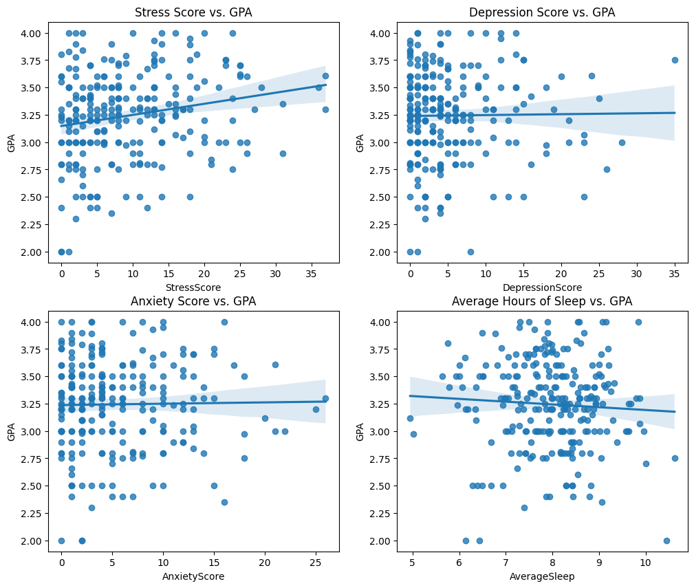

```python
#Create a 2x2 grid containing scatterplots and corresponding regression lines to see effect of StressScore,
#DepressionScore, AnxietyScore, and AverageSleep on GPA
figure, axis = plt.subplots(2, 2, figsize = (12,10))
sns.regplot(data = df, x = 'StressScore', y = 'GPA', ax = axis[0,0])
axis[0, 0].set_title('Stress Score vs. GPA')

sns.regplot(data = df, x = 'DepressionScore', y = 'GPA', ax = axis[0,1])
axis[0, 1].set_title('Depression Score vs. GPA')

sns.regplot(data = df, x = 'AnxietyScore', y = 'GPA', ax = axis[1,0])
axis[1, 0].set_title('Anxiety Score vs. GPA')

sns.regplot(data = df, x = 'AverageSleep', y = 'GPA', ax = axis[1,1])
axis[1, 1].set_title('Average Hours of Sleep vs. GPA')
```

The two graphs below show weekend and weekday bedtimes versus the average hours of sleep a student gets as differentiated by AM and PM. On the left side of the graphs are times after midnight and the right sides are times before midnight. When looking at the two graphs, it can be seen that there is no clear difference between going to bed early or late (before or after midnight) during both weekdays and weekends. In both instances of weekdays and weekends, the average hours of sleep that students get is vertically clustered on either end of the charts. This means that regardless of what time students go to bed in either instance, there is no clear impact of bedtime on the amount of sleep they get. In order to verify this, we ran summary statistics and found that the difference in the average hours of sleep between AM and PM bedtimes for both weekdays and weekends was not more than hour. This very slight difference made us feel that there was not a significant enough amount of variability to use these variables in our analysis.

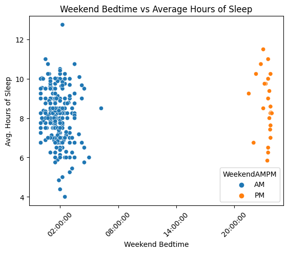

```python
# Creates scatterplot that shows the relationship between the time people sleep on weekends vs the number
# of hours they sleep
ax = sns.scatterplot(data=df, x="WeekendBed", y="WeekendSleep", hue="WeekendAMPM")
ax.set_title('Weekend Bedtime vs Average Hours of Sleep')
ax.set_xlabel('Weekend Bedtime')
ax.set_ylabel('Avg. Hours of Sleep')

# Adjusts x-axis such that time is in increments of 6 hours
ax.xaxis.set_major_locator(mdates.HourLocator(interval = 6))
ax.xaxis.set_major_formatter(mdates.DateFormatter("%H:%M:%S"))
# Positions x-axis ticks diagonally
ax.tick_params(axis="x", rotation=45)
```

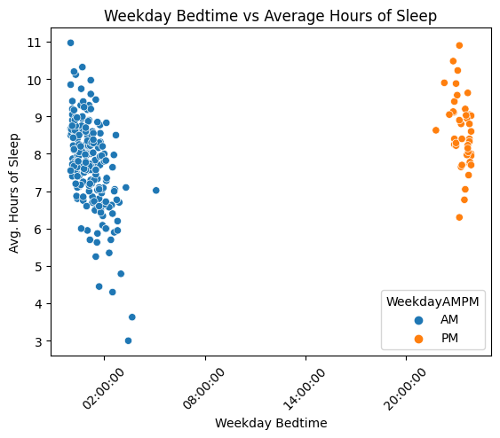

```python
# Creates scatterplot that shows the relationship between the time people sleep on weekdays vs the number
# of hours they sleep
ax = sns.scatterplot(data=df, x="WeekdayBed", y="WeekdaySleep", hue="WeekdayAMPM")
ax.set_title('Weekday Bedtime vs Average Hours of Sleep')
ax.set_xlabel('Weekday Bedtime')
ax.set_ylabel('Avg. Hours of Sleep')

# Adjusts x-axis such that time is in increments of 6 hours
ax.xaxis.set_major_locator(mdates.HourLocator(interval = 6))
ax.xaxis.set_major_formatter(mdates.DateFormatter("%H:%M:%S"))
# Positions x-axis ticks diagonally
ax.tick_params(axis="x", rotation=45)
```

```python
# Describes distributions of amount of time slept on both weekends and weekdays based on
# if people went to sleep early (within the night - pm) or late (after midnight - am)
print(df.groupby('WeekendAMPM')['WeekendSleep'].describe())
print(df.groupby('WeekdayAMPM')['WeekdaySleep'].describe())
```

```
             count      mean       std   min     25%    50%     75%    max
WeekendAMPM
AM           229.0  8.169476  1.338979  4.00  7.2500  8.250  9.1300  12.75
PM            24.0  8.672917  1.567092  5.84  7.5775  8.545  9.8125  11.50
             count      mean       std  min     25%   50%     75%    max
WeekdayAMPM
AM           210.0  7.719381  1.155374  3.0  7.0925  7.78  8.4725  10.97
PM            43.0  8.582093  0.952482  6.3  7.9850  8.40  9.0800  10.90
```

After performing this exploratory analysis, we wanted to more specifically understand the correlation between the variables to see how to most appropriately build our model by creating a correlation matrix with the seven variables we spent time investigating. There are two key points that we wanted to bring up from this correlation matrix. The first was that WeekdaySleep and AverageSleep are seen to be very highly correlated with a correlation coefficient of 0.92. While this seems intriguing, we wanted to note that this high value comes from the fact that AverageSleep is derived from WeekdaySleep so it is to be expected that these two are correlated in this way. The second point is the negative/low correlations between GPA and variables like DepressionScore, AnxietyScore, StressScore, and AverageSleep. When we were exploring the data, we expected there to be some correlation between these factors so these negative/low correlation coefficients were surprising to us. Because of this, we decided to explore those four variables further to understand why this was case. After creating histograms to look at the distributions of these four variables, we found that DepressionScore, AnxietyScore, and StressScore all had skewed distributions and AverageSleep's distribution was normal. The skewness of these three variables was causing an issue in the way their correlationn to GPA was calculated, so we thought it would be important to normalize the distributions in some way. This normalization will be further discussed in the Hypothesis Testing section.

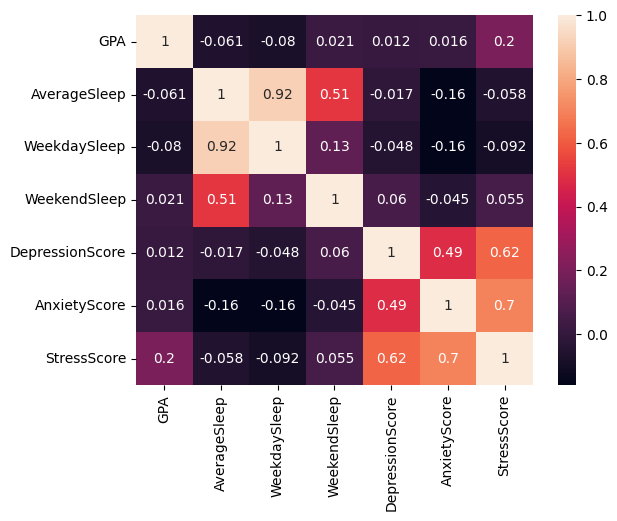

```python
#Correlation matrix with GPA, WeekendBed, WeekdayBed, AverageSleep, DepressionScore, AnxietyScore, and StressScore
corrDF = df[['GPA', 'AverageSleep', 'WeekdaySleep', 'WeekendSleep', 'DepressionScore', 'AnxietyScore', 'StressScore']]
corrDF.head()
corrMatrix = corrDF.corr()
corrMatrix
sns.heatmap(corrMatrix, annot = True)
```

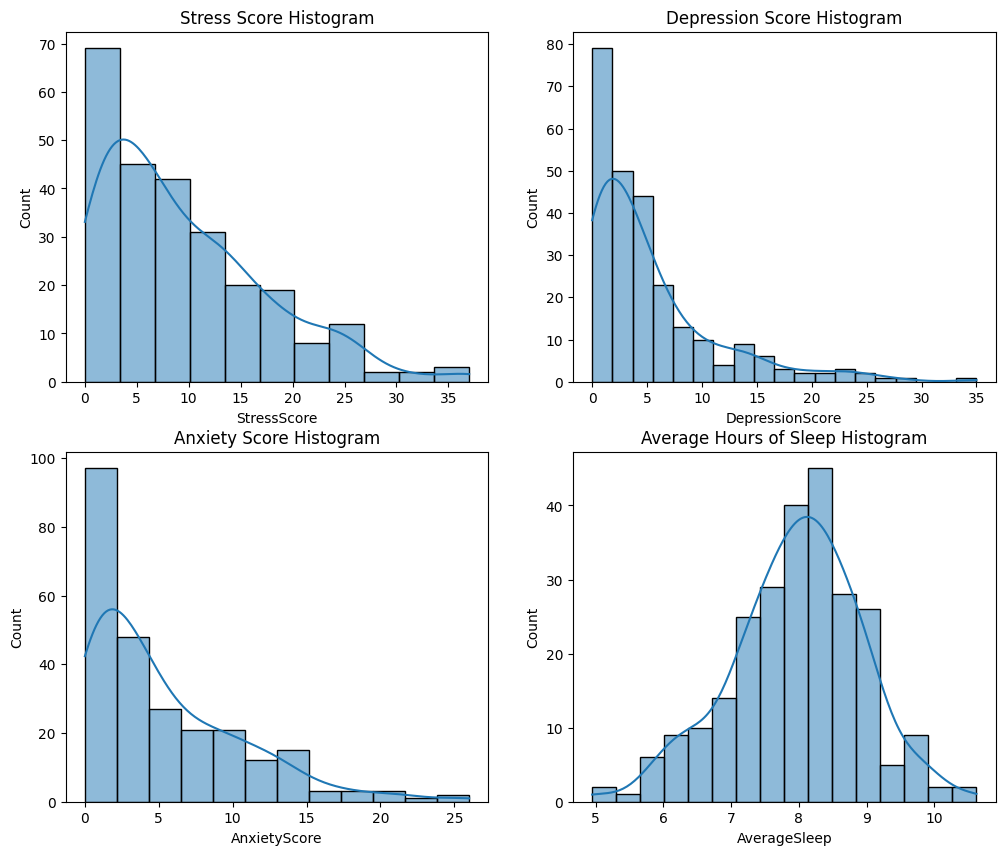

```python
figure, axis = plt.subplots(2, 2, figsize = (12,10))
sns.histplot(data = df, x = 'StressScore', kde = True, ax = axis[0,0])
axis[0, 0].set_title('Stress Score Histogram')

sns.histplot(data = df, x = 'DepressionScore', kde = True, ax = axis[0,1])
axis[0, 1].set_title('Depression Score Histogram')

sns.histplot(data = df, x = 'AnxietyScore', kde = True, ax = axis[1,0])
axis[1, 0].set_title('Anxiety Score Histogram')

sns.histplot(data = df, x = 'AverageSleep', kde = True, ax = axis[1,1])
axis[1, 1].set_title('Average Hours of Sleep Histogram')
```

## Hypothesis Testing

After researching, we found a study conducted by the American Psychological Association that stated “more than 60% of college students met the criteria for at least one mental health problem”. As a result, we wanted to see whether mental health conditions and the amount of sleep students get affects their academic performance. Based on the data we had, we decided to measure students academic performance based on their GPA. However, in our exploratory analysis' correlation matrix, we found that there was very little correlation between stress score and gpa, depression score and gpa, anixety score and gpa, and average sleep and gpa. We wanted to further evaluate the situation to see if there was truly no significant impact of sleep/mental health conditions on academic performance and decided to conduct hypothesis tests.

### Multiple Regression Model

First, we decided to create a multiple regression model. In this model, we will use StressScore, DepressionScore, AnxietyScore, and Average Sleep as predictors and GPA as a response variable. However, from the histograms of stress score, depression score, anxiety score, and average sleep in the exploratory analysis, we found that stress score, depression score, and anxiety score portrayed a skewed distribution. Before conducting a linear regression, we first have to make sure none of the assumptions are violated. These assumptions are:

1. Linear Relationship: there must be a linear relationship between the independent and dependent variable
2. Independence: The residuals should be independent
3. Homoscedasticity: The residuals should have a constant variance
4. Normality: the model should exhibit a normal distribution

[Linear Regression Assumptions](https://www.statology.org/linear-regression-assumptions/)

However, since the data appears to be skewed for 3 of the predictors, the normality assumption is violated. In additon, we constructed the residual plots for the 4 predictors in the figure below. The plots for stress score, depression score, and anxiety score appear to be cone-shaped instead of randomly distributed along the x-axis, which shows that the homoscedasticity assumption is violated as well as there is not a constant variance in the residual plot. Also, in the regression plots in the exploratory analysis that show the relationship between gpa vs the 4 predictors individually, there is no majorly linear relationship, which violates the linear relationship assumption.

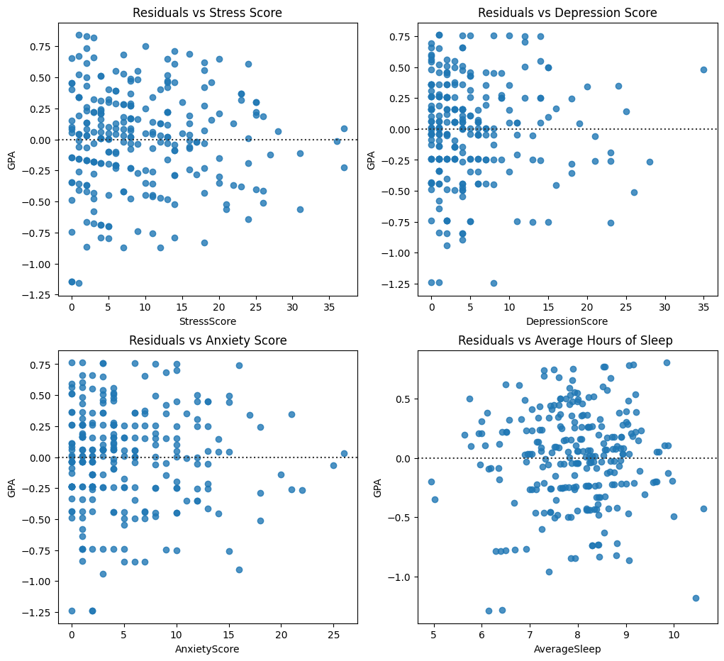

```python
figure, axis = plt.subplots(2, 2, figsize = (12,11))

sns.residplot( data=df, x='StressScore', y='GPA', ax = axis[0,0])
axis[0, 0].set_title('Residuals vs Stress Score')
sns.residplot( data=df, x='DepressionScore', y='GPA', ax = axis[0,1])
axis[0, 1].set_title('Residuals vs Depression Score')
sns.residplot( data=df, x='AnxietyScore', y='GPA', ax = axis[1,0])
axis[1, 0].set_title('Residuals vs Anxiety Score')
sns.residplot( data=df, x='AverageSleep', y='GPA', ax = axis[1,1])
axis[1, 1].set_title('Residuals vs Average Hours of Sleep ')
```

To make the data less skewed and represent a more normal distribution, we can perform a transformation on the skewed predictors. There are several transformation that we should consider. Below are 3 commonly used [transformations](https://medium.com/@muhammadibrahim_54071/why-and-which-data-transformation-should-i-use-cfb9e31923cf) and when we should use them.

1. Log tranformation:
   - Only transforming predictors:
     - Should be performed when the linear relationship assumption is violated but all other assumptions hold true. Non-linearity should be the ONLY violation. This transformation will linearize the relationship between variables.
   - Only transforming response:
     - Should be performed when the normality and constant variance (homoscedasticity) assumptions are violated. This transformation will linearize a relationship and also give a more constant variance amongst error terms.
   - Transforming predictors and response:
     - This transformation should be considered when most or all assumptions of linear regression are violated. Transforming the predictors will fix the non-linearity issue, and transforming the y valies will fix the constant variance violation.
2. Reciprocal transformation:
   - Should be used for data that portrays a positive skew. This transformation will reverse order amongst values that have the same positive or negative value
3. Square root trasnformation:
   - This tranformation should be performed when variance is proprotional to the mean.

For the purpose of our hypothesis test, we will perform a log transformation on both the predictor and response variables since close to all linear regression assumptions are violated. This tranformation will resolve the most issues in comparison to the other transformations listed above.

*To prevent -infinity values, use a log(x+1) transformation instead of log(x). As x approaches 0, log(x) can approach -infinity*

```python
# Creates columns the reflect the log(x+1) value where x is the original pre-transformed value
df['logStressScore'] = np.log1p(df['StressScore'])
df['logDepressionScore'] = np.log1p(df['DepressionScore'])
df['logAnxietyScore'] = np.log1p(df['AnxietyScore'])
df['logGPA'] = np.log1p(df['GPA'])
df.head()
```

|  | Gender | GPA | ClassesMissed | PoorSleepQuality | DepressionScore | AnxietyScore | StressScore | DepressionStatus | AnxietyStatus | Stress | ... | WeekendBed | WeekendSleep | AverageSleep | Sex | WeekendAMPM | WeekdayAMPM | logStressScore | logDepressionScore | logAnxietyScore | logGPA |
| --- | --- | --- | --- | --- | --- | --- | --- | --- | --- | --- | --- | --- | --- | --- | --- | --- | --- | --- | --- | --- | --- |
| 0 | 0 | 3.60 | 0 | 4 | 4 | 3 | 8 | normal | normal | normal | ... | 2022-12-16 01:45:00 | 5.88 | 7.18 | Female | AM | AM | 2.197225 | 1.609438 | 1.386294 | 1.526056 |
| 1 | 0 | 3.24 | 0 | 6 | 1 | 0 | 3 | normal | normal | normal | ... | 2022-12-16 02:00:00 | 7.25 | 6.93 | Female | AM | AM | 1.386294 | 0.693147 | 0.000000 | 1.444563 |
| 2 | 0 | 2.97 | 12 | 18 | 18 | 18 | 9 | moderate | severe | normal | ... | 2022-12-16 04:00:00 | 10.09 | 5.02 | Female | AM | AM | 2.302585 | 2.944439 | 2.944439 | 1.378766 |
| 3 | 0 | 3.76 | 0 | 9 | 1 | 4 | 6 | normal | normal | normal | ... | 2022-12-16 03:00:00 | 7.25 | 6.90 | Female | AM | PM | 1.945910 | 0.693147 | 1.609438 | 1.560248 |
| 4 | 0 | 3.20 | 4 | 9 | 7 | 25 | 14 | normal | severe | normal | ... | 2022-12-16 23:45:00 | 7.00 | 6.35 | Female | PM | AM | 2.708050 | 2.079442 | 3.258097 | 1.435085 |

5 rows × 26 columns

After performing a log transformation on both the predictor and response variables, we re-create the rediual plots and histograms to see if there is any difference. We can see that the residual plots appear less cone-shaped and more randomly distributed across the x-axis, so the constant variance (homoscedasticity) assumption is no longer violated. In addition, the histogram appears to show a more normal distribution instead of a skewed as well. As a result, this transformation helped fix the linear regression assumption violations, so now we can proceed with creating our multiple regression model.

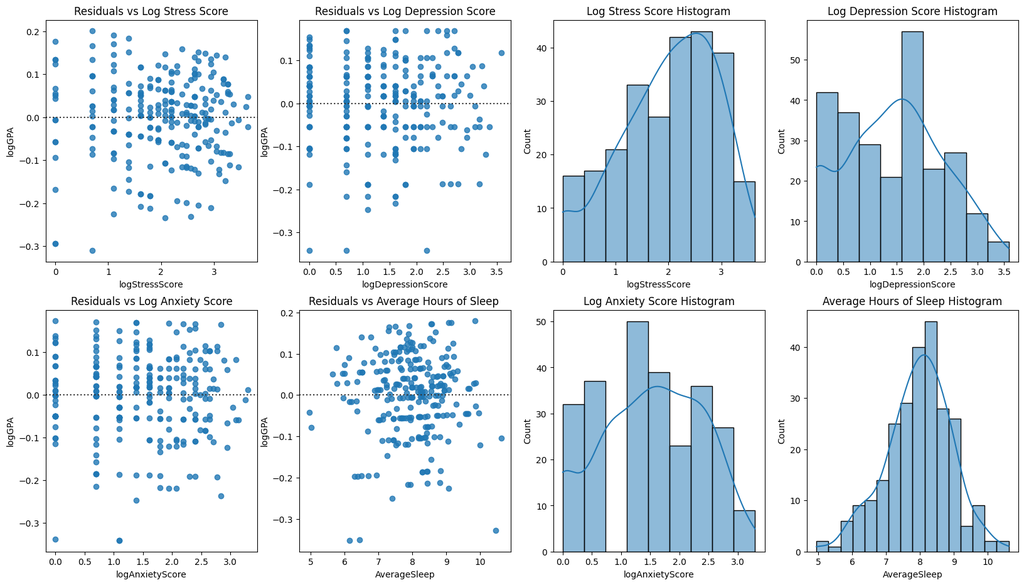

```python
figure, axis = plt.subplots(2, 4, figsize = (20,11))

# Creates residual plots using newly log transformed variables
sns.residplot( data=df, x='logStressScore', y='logGPA', ax = axis[0,0])
axis[0, 0].set_title('Residuals vs Log Stress Score')
sns.residplot( data=df, x='logDepressionScore', y='logGPA', ax = axis[0,1])
axis[0, 1].set_title('Residuals vs Log Depression Score')
sns.residplot( data=df, x='logAnxietyScore', y='logGPA', ax = axis[1,0])
axis[1, 0].set_title('Residuals vs Log Anxiety Score')
sns.residplot( data=df, x='AverageSleep', y='logGPA', ax = axis[1,1])
axis[1, 1].set_title('Residuals vs Average Hours of Sleep ')

# Creates histograms using newly log transformed variables
sns.histplot(data = df, x = 'logStressScore', kde = True, ax = axis[0,2])
axis[0, 2].set_title('Log Stress Score Histogram')
sns.histplot(data = df, x = 'logDepressionScore', kde = True, ax = axis[0,3])
axis[0, 3].set_title('Log Depression Score Histogram')
sns.histplot(data = df, x = 'logAnxietyScore', kde = True, ax = axis[1,2])
axis[1, 2].set_title('Log Anxiety Score Histogram')
sns.histplot(data = df, x = 'AverageSleep', kde = True, ax = axis[1,3])
axis[1, 3].set_title('Average Hours of Sleep Histogram')
```

To perform this test, we will set the following null and alternative hypothesis where each β represents one of the predictors:

H0: β1 = β2 = β3 = β4 = 0

Ha: At least one of these β’s is not 0

We will be using a α = 0.05 in this test, so if the p-value outputted by the regression model is less than 0.05, we will reject the null hypothesis at the 5% significance level.

**Note: For stress score, depression score, anxiety score, and gpa, we will be using the log transformed fields**

```python
# sets x to equal the predictor fields in the data frame
x = df[['logStressScore', 'logDepressionScore', 'logAnxietyScore', 'AverageSleep']]
# sets y to equal the response variable
y = df['logGPA']
x = sm.add_constant(x)
# creates linear model and stores it in variable lm
lm = sm.OLS(y, x).fit()
# prints regression model statistics
lm.summary()
```

OLS Regression Results

| Dep. Variable: | logGPA | R-squared: | 0.111 |
| --- | --- | --- | --- |
| Model: | OLS | Adj. R-squared: | 0.096 |
| Method: | Least Squares | F-statistic: | 7.709 |
| Date: | Fri, 16 Dec 2022 | Prob (F-statistic): | 7.18e-06 |
| Time: | 17:38:09 | Log-Likelihood: | 242.56 |
| No. Observations: | 253 | AIC: | -475.1 |
| Df Residuals: | 248 | BIC: | -457.5 |
| Df Model: | 4 |  |  |
| Covariance Type: | nonrobust |  |  |

|  | coef | std err | t | P>\|t\| | [0.025 | 0.975] |
| --- | --- | --- | --- | --- | --- | --- |
| const | 1.4360 | 0.052 | 27.376 | 0.000 | 1.333 | 1.539 |
| logStressScore | 0.0556 | 0.010 | 5.456 | 0.000 | 0.036 | 0.076 |
| logDepressionScore | -0.0222 | 0.008 | -2.640 | 0.009 | -0.039 | -0.006 |
| logAnxietyScore | -0.0256 | 0.010 | -2.661 | 0.008 | -0.045 | -0.007 |
| AverageSleep | -0.0046 | 0.006 | -0.748 | 0.455 | -0.017 | 0.008 |

| Omnibus: | 11.386 | Durbin-Watson: | 1.987 |
| --- | --- | --- | --- |
| Prob(Omnibus): | 0.003 | Jarque-Bera (JB): | 11.614 |
| Skew: | -0.500 | Prob(JB): | 0.00301 |
| Kurtosis: | 3.317 | Cond. No. | 77.0 |

Notes:  
[1] Standard Errors assume that the covariance matrix of the errors is correctly specified.

After creating the regression model and viewing the summary statistics, we can see that p-value for all of the predictors is below 0.05 except for the AverageSleep variable. This means that AverageSleep is not a significant predictor of GPA. Keeping a value that is not a signficant predictor can negatively impact the accuracy of the model, as it is including a predictor in which there is no sufficient evidence that it affects the response. So to make the model more efficient, we should consider removing this variable as a predictor.

Below, we have created a new regression model that removes AverageSleep as a predictor. Our new hypothesis is as follows:

H0: β1 = β2 = β3 = 0

Ha: At least one of these β’s is not 0

```python
# sets x to equal the predictor fields in the data frame
x = df[['logStressScore', 'logDepressionScore', 'logAnxietyScore']]
# sets y to equal the response variable
y = df['logGPA']
x = sm.add_constant(x)
# creates linear model and stores it in variable lm
lm = sm.OLS(y, x).fit()
# prints regression model statistics
lm.summary()
```

OLS Regression Results

| Dep. Variable: | logGPA | R-squared: | 0.109 |
| --- | --- | --- | --- |
| Model: | OLS | Adj. R-squared: | 0.098 |
| Method: | Least Squares | F-statistic: | 10.11 |
| Date: | Fri, 16 Dec 2022 | Prob (F-statistic): | 2.62e-06 |
| Time: | 17:38:09 | Log-Likelihood: | 242.27 |
| No. Observations: | 253 | AIC: | -476.5 |
| Df Residuals: | 249 | BIC: | -462.4 |
| Df Model: | 3 |  |  |
| Covariance Type: | nonrobust |  |  |

|  | coef | std err | t | P>\|t\| | [0.025 | 0.975] |
| --- | --- | --- | --- | --- | --- | --- |
| const | 1.3983 | 0.014 | 96.939 | 0.000 | 1.370 | 1.427 |
| logStressScore | 0.0557 | 0.010 | 5.481 | 0.000 | 0.036 | 0.076 |
| logDepressionScore | -0.0224 | 0.008 | -2.664 | 0.008 | -0.039 | -0.006 |
| logAnxietyScore | -0.0251 | 0.010 | -2.612 | 0.010 | -0.044 | -0.006 |

| Omnibus: | 10.371 | Durbin-Watson: | 1.974 |
| --- | --- | --- | --- |
| Prob(Omnibus): | 0.006 | Jarque-Bera (JB): | 10.502 |
| Skew: | -0.486 | Prob(JB): | 0.00524 |
| Kurtosis: | 3.227 | Cond. No. | 8.84 |

Notes:  
[1] Standard Errors assume that the covariance matrix of the errors is correctly specified.

Now since the p-value of all the predictors are less than 0.05, we can reject our null hypothesis at the 5% significance level. This means that at least one of the coefficients (β1, β2, or β3) is significant in explaining the variation in the response (GPA). However, the R-sq value is 0.109 which means that only 10.9% of the variation in gpa can be explained by the regression model with stress score, depression score, and anixety score as predictors. This is a relatively low number, so the model does not effectively explain the relationship between the data.

### Random Forest Model

In this model, the x variables are logStressScore, logDepressionScore, and logAnxietyScore. We chose to use the log transformed values for these three variables in order to both maintain consistency from the linear regression model and to ensure that the normally distributed values were used in the model as to use more accurate correlation values to logGPA. Although AverageSleep was used as one of the variables in the linear regression model, we felt that it would be better to not include it in here because of it's high p-value of 0.455. The lack of correlation to logGPA that this shows makes it a somehwat irrelevant variable in our analysis and this irrelevance can negatively impact the accuracy of the model.

We decided to create a train/test split of 70% to 30% since this is a common split used in data science. When selecting our hyperparameters, we chose to use n_estimators, max_features, and min_samples_split. For n_estimators, we gave options of 5, 10, 50, 100, 150, and 200 to test how mayn decision trees should be created in order to produce the most effective model. Because the default value for this hyperparameter is 100, we thought it would be beneficial to give values both above and below this to see how the number of estimators impacts the accuracy. When deciding to choose max_features as a second hyperparameter, we were thinking about the idea that if all featture are considered in all of the splits, the random forest will then have identical trees. To avoid this problem, we provided values of sqrt, log2, 0.25, 0.5, 0.75, and 1.0 so that the model could select the proportion of features that would yield the most accurate results. Finally, we chose to include min_samples_split as a hyperparameter to decide thet minimum amount of samples needed to split a nonterminal mode. A value that is too high can result in underfitting as it can restrict a model from learning relationships and a value that is too low can result in overfitting as it can lead to less generalization of the model. We provided the options of 2, 4, and 6 to accomodate various samples sizes and determine which would result in the most accurate random forest model. While there are other hyperparameters, we felt that these 3 would most significantly impact the model's accuracy and felt that they would be best to consider.

To choose the best hyperparameters, we ran [GridSearchCV](https://scikit-learn.org/stable/modules/generated/sklearn.model_selection.GridSearchCV.html) with a 10-fold cross validation in order to test all possible combinations of the hyperparameters to determine which was actually the best in terms of model accuracy. We chose GridSearchCV over [RandomizedSearchCV](https://scikit-learn.org/stable/modules/generated/sklearn.model_selection.RandomizedSearchCV.html) because we wanted to try out all possible hyperparameters to find the optimal set rather than only trying a fixed number of hyperparameter settings and leaving space for there to be a higher degree of inaccuracy in the model than necessary. After running this GridSearchCV, we were able to find that the optimal combination of hyperparameters for the model was an n_estimators value of 100, max_features value of sqrt, and min_samples_split value of 6. These chosen hyperparameters were used when the random forest regressor was run to predict values based on the test data for the x variables.

```python
# X is set to the predictors
X = df[['logStressScore', 'logDepressionScore', 'logAnxietyScore']]
# y is set to the response variable
y = df['logGPA']
# Sets test/train data where 70% is training and 30% is test
X_train, X_test, y_train, y_test = train_test_split(X, y, test_size=0.3, random_state=1)

# Provides various potential input parameters so that model can test out which combination works best
rf_params = {
    'n_estimators': [5, 10, 50, 100, 150, 200],
    'max_features': ['sqrt','log2', 0.25, 0.5, 0.75, 1.0],
    'min_samples_split': [2, 4, 6]
}

rf_model = RandomForestRegressor(random_state=1)
# Performs grid search cross validation on random forest model with provided model paramaters as inputs
grid_search = GridSearchCV(rf_model, rf_params, cv=10)
# Trains grid_search model with train data
grid_search.fit(X_train, y_train)
# Obtains the optimal hyperparameter values
print(grid_search.best_params_)
hyperparameters = list(grid_search.best_params_.values())
hyperparameters
```

```
{'max_features': 'sqrt', 'min_samples_split': 6, 'n_estimators': 100}
```

```
['sqrt', 6, 100]
```

```python
# Creates new random forest model with optimal hyperparameters
rf_model2 = RandomForestRegressor(max_features = hyperparameters[0], min_samples_split = hyperparameters[1], n_estimators = hyperparameters[2], random_state=1)
# Trains new model with train data
rf_model2.fit(X_train, y_train)
# obtains mean squared error score through cross validation with test data
preds = rf_model2.predict(X_test)
print(mean_squared_error(y_test, preds))
```

```
0.009377802321804468
```